# Fake News NLP Binary Classifier

Philip Situmorang, Brandon Kleinman, Ben Sra Chongbanyatcharoen

# 1 Introduction

In this project we seek to create a model which predicts if a news article is fake or true. We follow the standard data science process to arrive at a model which we deem best fit to predict the validity of an article.

We analyze both the title and the text (content) of news articles, building separate models for each to see the efficacy of each in predicting whether a news article is fake or true.

The dataset we use was obtained through Kaggle (www.kaggle.com/datasets/clmentbisaillon/fake-and-real-news-dataset), and the poster, Clément Bisaillon, credits the following two sources for the data:

1. Ahmed H, Traore I, Saad S. “Detecting opinion spams and fake news using text classification”, Journal of Security and Privacy, Volume 1, Issue 1, Wiley, January/February 2018.
2. Ahmed H, Traore I, Saad S. (2017) “Detection of Online Fake News Using N-Gram Analysis and Machine Learning Techniques. In: Traore I., Woungang I., Awad A. (eds) Intelligent, Secure, and Dependable Systems in Distributed and Cloud Environments. ISDDC 2017. Lecture Notes in Computer Science, vol 10618. Springer, Cham (pp. 127-138).

# 2 Data Pre-processing

The dataset is subdivided into two files originally, Fake.csv and True.csv. Both files has a column for title and one column for text in describing the article. In this section we combine the two files into one “text” dataframe and one “title” dataframe, each with an assigned response variables 0 and 1. We then split the dataframe into train-test-validate sets. We use validation set only in the final testing and evaluation phase.

You can find the codes that we used to pre-process the data below.

```r
# read in
fake <- fread("Fake.csv")
true <- fread("True.csv")
```

```r
# set "y" to be response variable column
fake <- fake %>% mutate(y = as.factor(0))
true <- true %>% mutate(y = as.factor(1))
```

```r
# combines the two and assigns a unique id for the articles
combined <- rbind(fake, true) %>% mutate(id = as.factor(row_number()))
```

## 2.1 Title Extraction

```r
title <- combined$title
corpus.title <- VCorpus(VectorSource(title))
```

```r
# Converts all words to lowercase
mycorpus_title <- tm_map(corpus.title, content_transformer(tolower))

# Removes common English stopwords (e.g. "with", "i")
mycorpus_title <- tm_map(mycorpus_title, removeWords, stopwords("english"))

# Removes any punctuation
# NOTE: This step may not be appropriate if you want to account for differences
#       on semantics depending on which sentence a word belongs to if you end up
#       using n-grams or k-skip-n-grams.
#       Instead, periods (or semicolons, etc.) can be replaced with a unique
#       token (e.g. "[PERIOD]") that retains this semantic meaning.
mycorpus_title <- tm_map(mycorpus_title, removePunctuation)

# Removes numbers
mycorpus_title <- tm_map(mycorpus_title, removeNumbers)

# Stem words
mycorpus_title <- tm_map(mycorpus_title, stemDocument, lazy = TRUE)
```

```r
dtm1.title <- DocumentTermMatrix(mycorpus_title)
```

```r
threshold <- .005*length(mycorpus_title)   # .5% of the total documents = .005 of the total documents
words.title <- findFreqTerms(dtm1.title, lowfreq=threshold)
dtm2.title <- DocumentTermMatrix(mycorpus_title, control = list(dictionary = words.title))
dim(dtm2.title)
```

```r
title <- cbind(dtm2.title, combined$y, combined$id)
title <- data.frame(as.matrix(title))
title <- title %>% rename(y = V343) %>% rename(id = V344)
dim(title)
#title[,343:344]
```

## 2.2 2-gram Title Extraction

```r
# The 'n' for n-grams
# n=2 is bi-grams
n <- 2

# Our custom tokenizer
# Uses the ngrams function from the NLP package
# Right now this is for bigrams, but you can change it by changing the value of
# the variable n (includes N-grams for any N <= n)
ngram_tokenizer <- function(x, n) {
  unlist(lapply(ngrams(words(x), 1:n), paste, collapse = "_"), use.names = FALSE)
}
```

```r
# use ngram_tokenizer()
control_list_ngram <- list(tokenize = function(x) ngram_tokenizer(x, 2))

dtm.title.ngram <- DocumentTermMatrix(mycorpus_title, control_list_ngram)
```

```r
dtm.title.ngram <- removeSparseTerms(dtm.title.ngram, 1-.001)
inspect(dtm.title.ngram )
```

```r
title.ngram <- cbind(dtm.title.ngram, combined$y, combined$id)
title.ngram <- data.frame(as.matrix(title.ngram))
title.ngram <- title.ngram %>% rename(y = V1886) %>% rename(id = V1887)
#dim(title.ngram)
#title.ngram[,1880:1887]
```

## 2.3 Text Extraction

```r
text <- combined$text
corpus.text <- VCorpus(VectorSource(text))
```

```r
# Converts all words to lowercase
mycorpus_text <- tm_map(corpus.text, content_transformer(tolower))

# Removes common English stopwords (e.g. "with", "i")
mycorpus_text <- tm_map(mycorpus_text, removeWords, stopwords("english"))

# Removes any punctuation
# NOTE: This step may not be appropriate if you want to account for differences
#       on semantics depending on which sentence a word belongs to if you end up
#       using n-grams or k-skip-n-grams.
#       Instead, periods (or semicolons, etc.) can be replaced with a unique
#       token (e.g. "[PERIOD]") that retains this semantic meaning.
mycorpus_text <- tm_map(mycorpus_text, removePunctuation)

# Removes numbers
mycorpus_text <- tm_map(mycorpus_text, removeNumbers)

# Stem words
mycorpus_text <- tm_map(mycorpus_text, stemDocument, lazy = TRUE)
```

```r
dtm1.text <- DocumentTermMatrix(mycorpus_text)
```

**Discussion:**

Thresholds tried: .01, 3014 words remaining. .015, 2368 words remaining. .02, 1926 words remaining. .025, 1624 remaining.

```r
# takes a minute
threshold <- .025*length(mycorpus_text)   # 2.5% of the total documents
words.text <- findFreqTerms(dtm1.text, lowfreq=threshold)
dtm2.text <- DocumentTermMatrix(mycorpus_text, control = list(dictionary = words.text))
dim(dtm2.text)
```

```r
text <- cbind(dtm2.text, combined$y, combined$id)
text <- data.frame(as.matrix(text))
text <- text %>% rename(y = V1625)%>% rename(id = V1626)
dim(text)
#text[,1620:1626]
```

**Output data:**

```r
write.csv(title.ngram, "title.csv", row.names=FALSE)
write.csv(text, "text.csv", row.names=FALSE)
```

## 2.4 Train Test Validation Split

```r
title_df <- fread("title.csv")
text_df <- fread("text.csv")
```

```r
text_df_0 <- text_df %>% filter(y=="0")
text_df_1 <- text_df %>% filter(y=="1")

title_df_0 <- title_df %>% filter(y=="0")
title_df_1 <- title_df %>% filter(y=="1")
```

**Extract training data**

```r
set.seed(1)
n <- nrow(text_df_0)
train.index.0 <- sample(n, 16000)
text.train.0 <- text_df_0[train.index.0,]
text.train.leftover.0 <- text_df_0[-train.index.0,]

title.train.0 <- title_df_0[train.index.0,]
title.train.leftover.0 <- title_df_0[-train.index.0,]

dim(text.train.0)
dim(text.train.leftover.0)

dim(title.train.0)
dim(title.train.leftover.0)
```

```r
set.seed(1)
n <- nrow(text_df_1)
train.index.1 <- sample(n, 15000)
text.train.1 <- text_df_1[train.index.1,]
text.train.leftover.1 <- text_df_1[-train.index.1,]

title.train.1 <- title_df_1[train.index.1,]
title.train.leftover.1 <- title_df_1[-train.index.1,]

dim(text.train.1)
dim(text.train.leftover.1)

dim(title.train.1)
dim(title.train.leftover.1)
```

```r
title_train <- rbind(title.train.0, title.train.1)
text_train <- rbind(text.train.0, text.train.1)
```

**Extract test and validation data**

```r
set.seed(1)
n.leftover <- nrow(text.train.leftover.0)
test.index.0 <- sample(n.leftover, 4000)

text.test.0 <- text.train.leftover.0[test.index.0,]
text.validate.0 <- text.train.leftover.0[-test.index.0,]

title.test.0 <- title.train.leftover.0[test.index.0,]
title.validate.0 <- title.train.leftover.0[-test.index.0,]

dim(text.test.0)
dim(text.validate.0)

dim(title.test.0)
dim(title.validate.0)
```

```r
set.seed(1)
n.leftover <- nrow(text.train.leftover.1)
test.index.1 <- sample(n.leftover, 3000)

text.test.1 <- text.train.leftover.1[test.index.1,]
text.validate.1 <- text.train.leftover.1[-test.index.1,]

title.test.1 <- title.train.leftover.1[test.index.1,]
title.validate.1 <- title.train.leftover.1[-test.index.1,]

dim(text.test.1)
dim(text.validate.1)

dim(title.test.1)
dim(title.validate.1)
```

```r
title_test <- rbind(title.test.0, title.test.1)
text_test <- rbind(text.test.0, text.test.1)
```

```r
title_validate <- rbind(title.validate.0, title.validate.1)
text_validate <- rbind(text.validate.0, text.validate.1)

#title_validate[,1880:1887]
#text_validate[,1620:1626]
```

**Output data:**

```r
write.csv(title_train, "title_train.csv", row.names=FALSE)
write.csv(text_train, "text_train.csv", row.names=FALSE)

write.csv(title_test, "title_test.csv", row.names=FALSE)
write.csv(text_test, "text_test.csv", row.names=FALSE)

write.csv(title_validate, "title_validate.csv", row.names=FALSE)
write.csv(text_validate, "text_validate.csv", row.names=FALSE)
```

# 3 Explanation on model creation

We will use logistic regression, neural net, and random forest to create models that predict whether an article is fake news or not. There will be two models created using each method: one will use the article’s text data for prediction, and the other will use the title data.

We have separated the next sections by the type of model that we use. (i.e. logistic regression, neural net, and random forest)

# 4 Logistic Regression

```r
train_test_df <- rbind(train_df, test_df)
```

```r
train_test_id <- train_test_df %>% select(id)
validate_id <- validate_df %>% select(id)
```

```r
train.data <- combined[combined$id %in% train_test_id$id, ]
validate.data <- combined[combined$id %in% validate_id$id, ]
```

```r
totalData <- rbind(train.data, validate.data)
totalData <- totalData %>% rename(trueValue = y)
head(totalData)
```

```
## # A tibble: 6 × 6
##   title                   text                   subject date    trueValue    id
##   <chr>                   <chr>                  <chr>   <chr>       <dbl> <dbl>
## 1 Donald Trump Sends Out… Donald Trump just cou… News    Decemb…         0     1
## 2 Drunk Bragging Trump S… House Intelligence Co… News    Decemb…         0     2
## 3 Sheriff David Clarke B… On Friday, it was rev… News    Decemb…         0     3
## 4 Trump Is So Obsessed H… On Christmas day, Don… News    Decemb…         0     4
## 5 Racist Alabama Cops Br… The number of cases o… News    Decemb…         0     6
## 6 Fresh Off The Golf Cou… Donald Trump spent a … News    Decemb…         0     7
```

```r
data.text <- totalData$text
mycorpus1 <- VCorpus(VectorSource(data.text))
```

```r
# Converts all words to lowercase
mycorpus_clean <- tm_map(mycorpus1, content_transformer(tolower))
# Removes common English stopwords (e.g. "with", "i")
mycorpus_clean <- tm_map(mycorpus_clean, removeWords, stopwords("english"))
mycorpus_clean <- tm_map(mycorpus_clean, removePunctuation)
# Removes numbers
mycorpus_clean <- tm_map(mycorpus_clean, removeNumbers)
# Stem words
mycorpus_clean <- tm_map(mycorpus_clean, stemDocument, lazy = TRUE)
```

```r
dtm1 <- DocumentTermMatrix(mycorpus_clean)
```

```r
threshold <- .015*length(mycorpus_clean)
words.1 <- findFreqTerms(dtm1, lowfreq=threshold)
dtm2<- DocumentTermMatrix(mycorpus_clean, control = list(dictionary = words.1))
dim(dtm2)
```

```
## [1] 44898  2365
```

```r
fulldata <- data.frame(as.matrix(dtm2), totalData$trueValue, stringsAsFactors = FALSE)
fulldata <- fulldata %>% rename(trueValue = totalData.trueValue)
```

```r
set.seed(1)
n <- nrow(fulldata)
train.index <- c(seq(from = 0, to = nrow(train.data)))
train <- fulldata[train.index,]
test <- fulldata[-train.index,]
dim(train)
```

```
## [1] 38000  2366
```

```r
#dim(test) train$totalData.trueValue train[, 2090:2093] fulldata[, 2090:2093]
```

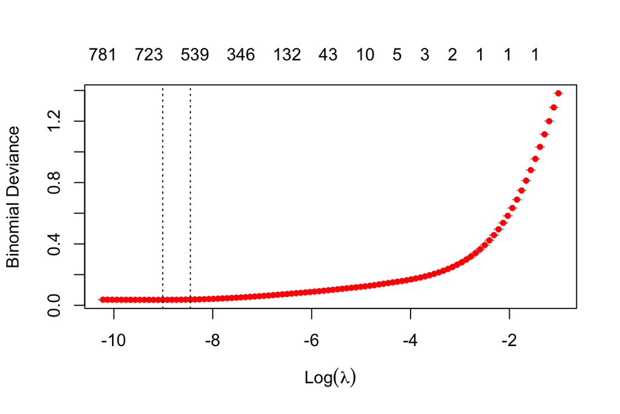

```r
response <- as.numeric(train$trueValue)
#
#data2.train$rating
#X1 <- sparse.model.matrix(rating~., data=data2.train)[, -1]
#X1$y
options(na.action='na.pass')
X1 <- sparse.model.matrix(trueValue~., data=train)[, -1]
options(na.action='na.action')
set.seed(1)
result.lasso <- cv.glmnet(X1, response, alpha=1, family="binomial")
plot(result.lasso)
```

```r
coef.1se <- coef(result.lasso, s="lambda.1se")
coef.1se <- coef.1se[which(coef.1se !=0),]
lasso.words <- rownames(as.matrix(coef.1se))[-1]
summary(lasso.words)
```

```
##    Length     Class      Mode
##       560 character character
```

```r
# pick up the positive coef's which are positively related to the prob of being a good review
good.glm <- coef.1se[which(coef.1se > 0)]
good.glm <- good.glm[-1]  # took intercept out
names(good.glm)[1:20]  # which words are positively associated with good ratings
```

```
##  [1] "X.ve"            "X..re"           "X..s"            "abil"
##  [5] "account"         "accus"           "achiev"          "administration."
##  [9] "adult"           "africa"          "age"             "allianc"
## [13] "amid"            "ankara"          "assembl"         "avail"
## [17] "bank"            "battl"           "beij"            "belong"
```

```r
good.fre <- sort(good.glm, decreasing = TRUE) # sort the coef's
round(good.fre, 4)[1:20] # leading 20 positive words, amazing!
```

```
##      reuter       don.t      trump.      party.      verifi        X..s
##      7.5592      2.4326      2.0309      1.9341      1.7957      1.6753
##    clinton.        edit      obama.        X.ve      state. predecessor
##      1.6231      1.4759      1.4701      1.3133      1.2099      1.1076
##     express        sept     newspap  president.     opinion   territori
##      0.8588      0.8431      0.7546      0.7321      0.6866      0.6018
##         nov       broad
##      0.5853      0.5633
```

```r
length(good.fre)  # 390 good words
```

```
## [1] 270
```

```r
# hist(as.matrix(good.fre), breaks=30, col="red")
good.word <- names(good.fre)  # good words with a decreasing order in the coeff's
```

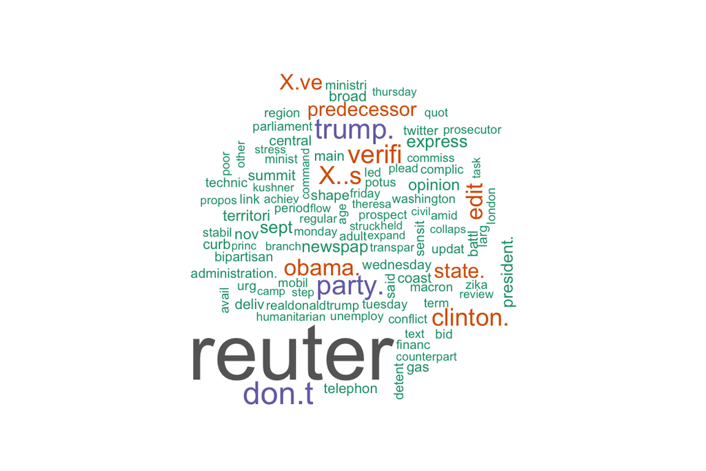

```r
cor.special <- brewer.pal(8,"Dark2")  # set up a pretty color scheme
wordcloud(good.word[1:100], good.fre[1:100],  # make a word cloud
          colors=cor.special, ordered.colors=F,min.freq = 100)
```

**Negative Word Cloud**

```r
bad.glm <- coef.1se[which(coef.1se < 0)]
cor.special <- brewer.pal(6,"Dark2")
bad.fre <- sort(-bad.glm, decreasing = TRUE)
```

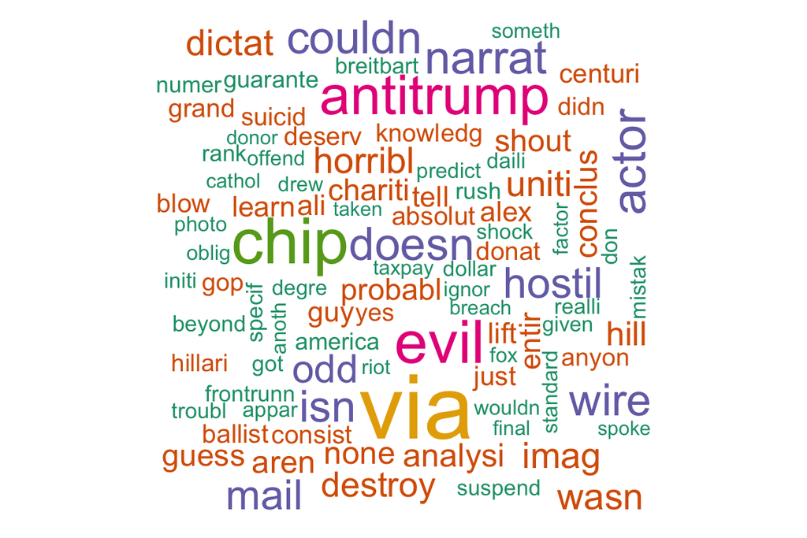

```r
bad.word <- names(bad.fre)
wordcloud(bad.word[2:100], bad.fre[2:100],color=cor.special, ordered.colors=F, min.freq = 100)
```

```r
#round(bad.fre, 4)[1:20]
```

```r
predict.lasso <- predict(result.lasso, as.matrix(test[, -1]), type = "class", s="lambda.1se")
  # output majority vote labels
# LASSO testing errors
mean(test$trueValue != predict.lasso)
```

```
## [1] 0.5
```

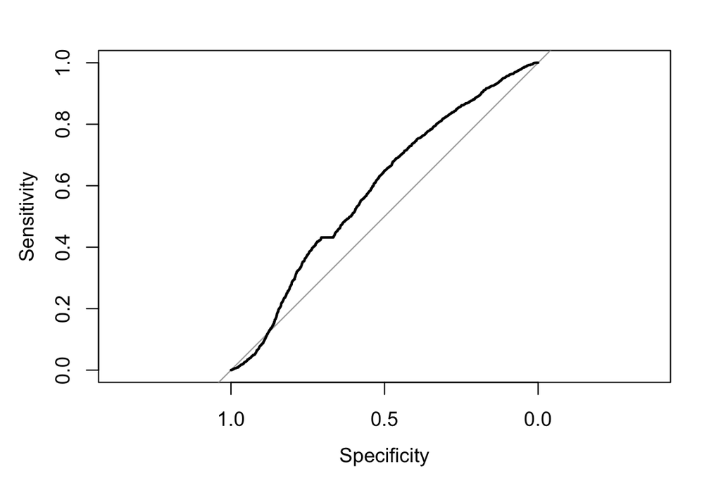

```
##
## Call:
## roc.default(response = test$trueValue, predictor = predict.lasso.p,     plot = TRUE)
##
## Data: predict.lasso.p in 3481 controls (test$trueValue 0) < 3417 cases (test$trueValue 1).
## Area under the curve: 0.5873
```

```r
predict.lasso.p <- predict(result.lasso, as.matrix(test[, -1]), type = "response", s="lambda.1se")
pROC::roc(test$trueValue, predict.lasso.p, plot=TRUE)
```

** Logistic Regression **

```r
options(na.action='na.pass')
sel_cols <- c("trueValue", lasso.words)
data_sub <- train %>% select(all_of(sel_cols))
result.glm <- glm(trueValue~., family=binomial, data_sub)
```

```r
predict.glm <- predict(result.glm, test, type = "response")
# Majority vote
class.glm <- ifelse(predict.glm > .5, "1", "0")
testerror.glm <- mean(test$trueValue != class.glm)
testerror.glm
```

```
## [1] 0.007538417
```

** titles **

```r
data.titles <- totalData$title
mycorpus2 <- VCorpus(VectorSource(data.titles))
```

```r
# Converts all words to lowercase
mycorpus_clean2 <- tm_map(mycorpus2, content_transformer(tolower))
# Removes common English stopwords (e.g. "with", "i")
mycorpus_clean2 <- tm_map(mycorpus_clean2, removeWords, stopwords("english"))
mycorpus_clean2 <- tm_map(mycorpus_clean2, removePunctuation)
# Removes numbers
mycorpus_clean2 <- tm_map(mycorpus_clean2, removeNumbers)
# Stem words
mycorpus_clean2 <- tm_map(mycorpus_clean2, stemDocument, lazy = TRUE)
```

```r
dtm3 <- DocumentTermMatrix(mycorpus_clean2)
```

```r
threshold2 <- .015*length(mycorpus_clean2)
words.2 <- findFreqTerms(dtm3, lowfreq=threshold2)
dtm4<- DocumentTermMatrix(mycorpus_clean2, control = list(dictionary = words.2))
dim(dtm4)
```

```
## [1] 44898    61
```

```r
fulldata2 <- data.frame(as.matrix(dtm4), totalData$trueValue, stringsAsFactors = FALSE)
fulldata2 <- fulldata2 %>% rename(trueValue = totalData.trueValue)
```

```r
set.seed(1)
n <- nrow(fulldata2)
train.index <- c(seq(from = 0, to = nrow(train.data)))
train2 <- fulldata2[train.index,]
test2 <- fulldata2[-train.index,]
dim(train2)
```

```
## [1] 38000    62
```

```r
#dim(test) train$totalData.trueValue train[, 2090:2093] fulldata[, 2090:2093]
```

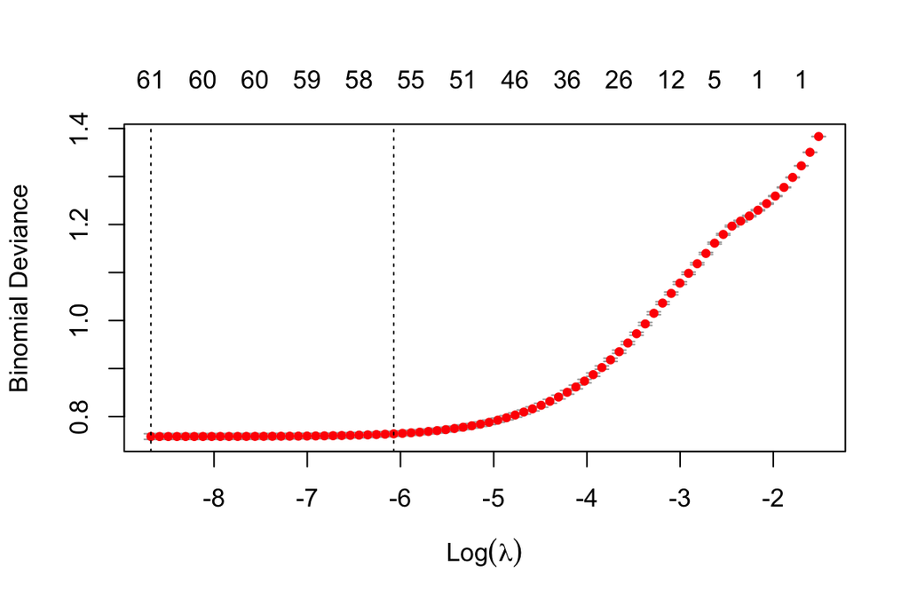

```r
response2 <- as.numeric(train2$trueValue)
#
#data2.train$rating
#X1 <- sparse.model.matrix(rating~., data=data2.train)[, -1]
#X1$y
options(na.action='na.pass')
X1_2 <- sparse.model.matrix(trueValue~., data=train2)[, -1]
options(na.action='na.action')
set.seed(1)
result.lasso2 <- cv.glmnet(X1_2, response2, alpha=1, family="binomial")
plot(result.lasso2)
```

```r
coef.1se_2 <- coef(result.lasso2, s="lambda.1se")
coef.1se_2 <- coef.1se_2[which(coef.1se_2 !=0),]
lasso.words2 <- rownames(as.matrix(coef.1se_2))[-1]
summary(lasso.words2)
```

```
##    Length     Class      Mode
##        56 character character
```

```r
# pick up the positive coef's which are positively related to the prob of being a good review
good.glm2 <- coef.1se_2[which(coef.1se_2 > 0)]
good.glm2 <- good.glm2[-1]  # took intercept out
names(good.glm2)[1:20]  # which words are positively associated with good ratings
```

```
##  [1] "attack"  "back"    "bill"    "china"   "clinton" "court"   "deal"
##  [8] "elect"   "hous"    "iran"    "kill"    "korea"   "leader"  "may"
## [15] "meet"    "north"   "offici"  "plan"    "polic"   "russia"
```

```r
good.fre2 <- sort(good.glm2, decreasing = TRUE) # sort the coef's
round(good.fre2, 4)[1:20] # leading 20 positive words, amazing!
```

```
##  china    say   hous   talk  north  senat    tax leader offici    may  court
## 1.9274 1.4236 1.3655 1.3368 1.1583 1.0663 1.0561 0.9293 0.9064 0.9006 0.8600
##  korea russia   deal   meet   iran   kill  polic  elect  state
## 0.8052 0.7960 0.7461 0.7057 0.5882 0.3714 0.3595 0.3298 0.2971
```

```r
length(good.fre2)  # 390 good words
```

```
## [1] 26
```

```r
# hist(as.matrix(good.fre), breaks=30, col="red")
good.word2 <- names(good.fre2)  # good words with a decreasing order in the coeff's
```

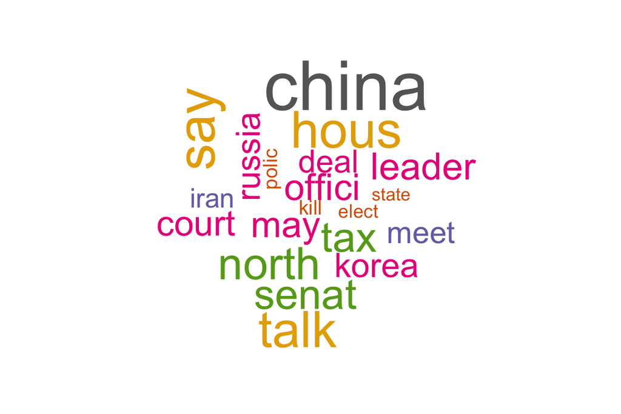

```r
cor.special2 <- brewer.pal(8,"Dark2")  # set up a pretty color scheme
wordcloud(good.word2[1:20], good.fre2[1:20],  # make a word cloud
          colors=cor.special2, ordered.colors=F)
```

**negative word cloud for titles**

```r
bad.glm2 <- coef.1se_2[which(coef.1se_2 < 0)]
cor.special2 <- brewer.pal(6,"Dark2")
bad.fre2 <- sort(-bad.glm2, decreasing = TRUE)
```

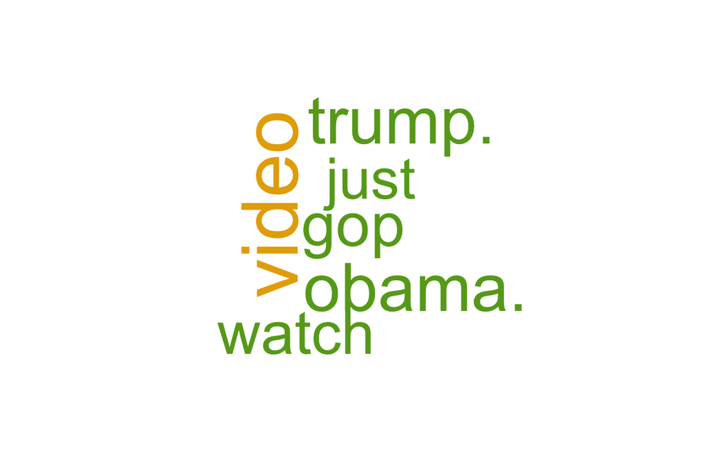

```r
bad.word2 <- names(bad.fre2)
wordcloud(bad.word2[1:10], bad.fre2[1:20],color=cor.special2, ordered.colors=F)
```

```r
#round(bad.fre, 4)[1:20]
```

** Logistic Regression **

```r
options(na.action='na.pass')
sel_cols2 <- c("trueValue", lasso.words2)
data_sub2 <- train2 %>% select(all_of(sel_cols2))
result.glm2 <- glm(trueValue~., family=binomial, data_sub2)
```

```r
predict.glm2 <- predict(result.glm2, test2, type = "response")
# Majority vote
class.glm2 <- ifelse(predict.glm2 > .5, "1", "0")
testerror.glm2 <- mean(test2$trueValue != class.glm2)
testerror.glm2
```

```
## [1] 0.1717889
```

# 5 Neural Net

### 5.0.1 Text

The codes for each step that we took is below. The conclusion on the final model is at the bottom.

```
## # A tibble: 6 × 6
##   title                    text                     subject date         y    id
##   <chr>                    <chr>                    <chr>   <chr>    <dbl> <dbl>
## 1 Donald Trump Sends Out … Donald Trump just could… News    Decembe…     0     1
## 2 Drunk Bragging Trump St… House Intelligence Comm… News    Decembe…     0     2
## 3 Sheriff David Clarke Be… On Friday, it was revea… News    Decembe…     0     3
## 4 Trump Is So Obsessed He… On Christmas day, Donal… News    Decembe…     0     4
## 5 Pope Francis Just Calle… Pope Francis used his a… News    Decembe…     0     5
## 6 Racist Alabama Cops Bru… The number of cases of … News    Decembe…     0     6
```

```r
train_test_df <- rbind(train_df, test_df)
```

```r
train_test_id <- train_test_df %>% select(id)
validate_id <- validate_df %>% select(id)
```

```r
write.csv(train_test_id, "train_test_id.csv", row.names=FALSE)
write.csv(validate_id, "validate_id.csv", row.names=FALSE)
```

#### 5.0.1.1 Split

```r
train.data <- combined[combined$id %in% train_test_id$id, ]
validate.data <- combined[combined$id %in% validate_id$id, ]
```

#### 5.0.1.2 Vectorize

```r
num_words <- 10000
max_length <- 1000
text_vectorization <- layer_text_vectorization(
  max_tokens = num_words,
  output_sequence_length = max_length,
)
```

```
## Loaded Tensorflow version 2.8.0
```

```r
text_vectorization %>%adapt(combined$text)
```

```r
get_vocabulary(text_vectorization)
```

[output not shown]

[output cut: 4985 more lines]

```r
text_vectorization(matrix(combined$text[1], ncol = 1))
```

```
## tf.Tensor(
## [[  69   18   81 1410   44 2435   56  234    5 1712   63  111    6  650
##     15   28    8  532   14   42    3  381    5 9442   57    3   20 3165
##   9512    6    2  143 4820  683   97  123    2  106  968  239 1298   42
##     81   54  461    3   91    6   14 1410   44   91   15   19   70  114
##   4615    1 2918    6    1   37  184    3 2435   56    4  175  956  333
##   3165 9512    6  108    2  143 4820  683   97  123    5 1712    6 4182
##     63  111   38 1650 6331 1024 1217   40   23    5  354  111   11  162
##     19   70  114 4615    1 2918    6    1   37  184    3 2435   56    4
##    175  956  333 3165 9512    6  108    2  143 4820  683   97  123    5
##   1712    6 4182   63  111 1217   40   23    5  354  111   11  162   69
##    813   18  801  602 1877 5186   10  834  356  163   39   19    1   19
##     43  614    1  730    4   38 5803    5   63  111   10    1   89   27
##   7233 6505    1    1  102   18   20 1277    4 7799  322   44  108  598
##     80    3 1394 1452    2    1  287  449    3 2435    2  135  593    5
```

[output cut: 58 more lines]

#### 5.0.1.3 Create Model

```r
input <- layer_input(shape = c(1), dtype = "string")
output <- input %>%
  text_vectorization() %>%
  layer_embedding(input_dim = num_words + 1, output_dim = 16) %>%
  layer_global_average_pooling_1d() %>%
  layer_dense(units = 16, activation = "relu") %>%
  layer_dropout(0.5) %>%
  layer_dense(units = 1, activation = "sigmoid")
model <- keras_model(input, output)
```

```r
model %>% compile(
  optimizer = 'adam',
  loss = 'binary_crossentropy',
  metrics = list('accuracy')
)
```

```r
set.seed(1)
history <- model %>% fit(
  train.data$text,
  as.numeric(train.data$y),
  epochs = 25,
  batch_size = 512,
  validation_split = 0.2,
  verbose=2
)
```

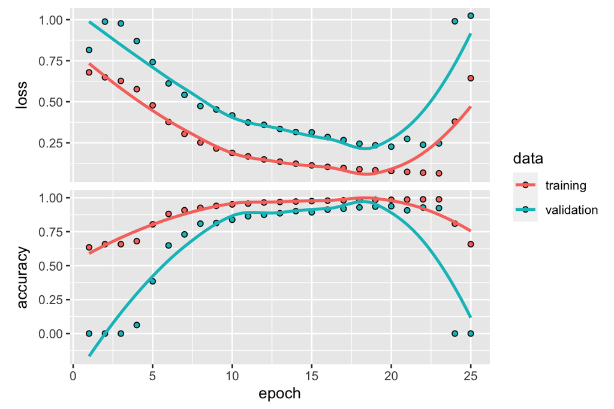

```r
plot(history)
```

#### 5.0.1.4 Model evaluation using validation dataset

```r
results <- model %>% evaluate(validate.data$text, as.numeric(validate.data$y), verbose = 0)
results
```

```
##      loss  accuracy
## 0.7318332 0.5046390
```

### 5.0.2 Title

The codes for each step that we took is below. The conclusion on the final model is at the bottom.

```
## # A tibble: 6 × 6
##   title                    text                     subject date         y    id
##   <chr>                    <chr>                    <chr>   <chr>    <dbl> <dbl>
## 1 Donald Trump Sends Out … Donald Trump just could… News    Decembe…     0     1
## 2 Drunk Bragging Trump St… House Intelligence Comm… News    Decembe…     0     2
## 3 Sheriff David Clarke Be… On Friday, it was revea… News    Decembe…     0     3
## 4 Trump Is So Obsessed He… On Christmas day, Donal… News    Decembe…     0     4
## 5 Pope Francis Just Calle… Pope Francis used his a… News    Decembe…     0     5
## 6 Racist Alabama Cops Bru… The number of cases of … News    Decembe…     0     6
```

#### 5.0.2.1 Split

```r
train.data <- combined[combined$id %in% train_test_id$id, ]
validate.data <- combined[combined$id %in% validate_id$id, ]
```

#### 5.0.2.2 Vectorize

```r
num_words <- 10000
max_length <- 25
text_vectorization <- layer_text_vectorization(
  max_tokens = num_words,
  output_sequence_length = max_length,
)
```

```r
text_vectorization %>%adapt(combined$title)
```

```r
get_vocabulary(text_vectorization)
```

[output not shown]

[output cut: 3319 more lines]

#### 5.0.2.3 Create Model

```r
input <- layer_input(shape = c(1), dtype = "string")
output <- input %>%
  text_vectorization() %>%
  layer_embedding(input_dim = num_words + 1, output_dim = 16) %>%
  layer_global_average_pooling_1d() %>%
  layer_dense(units = 16, activation = "relu") %>%
  layer_dropout(0.5) %>%
  layer_dense(units = 1, activation = "sigmoid")
model <- keras_model(input, output)
```

```r
model %>% compile(
  optimizer = 'adam',
  loss = 'binary_crossentropy',
  metrics = list('accuracy')
)
```

```r
set.seed(1)
history <- model %>% fit(
  train.data$title,
  as.numeric(train.data$y),
  epochs = 50,
  batch_size = 512,
  validation_split = 0.2,
  verbose=2
)
```

**Note:** 99.46% accuracy on training set after 50 epochs.

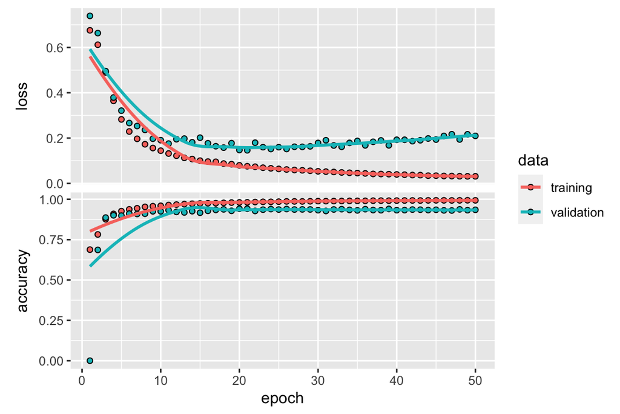

```r
plot(history)
```

#### 5.0.2.4 Model evaluation using validation dataset

```r
results <- model %>% evaluate(validate.data$title, as.numeric(validate.data$y), verbose = 0)
results
```

```
##      loss  accuracy
## 0.1445649 0.9623079
```

# 6 Random Forest

## 6.1 RF - text model

We used `ranger` to create our random forest model. We set `mtry` to be 1/3 of the number of predictors, and set `num.tree` to be higher than the threshold at which OBB MSE converges. We ended up with `mtry` = 542 and `num.tree` = 500

This is the code that we used to create the model:

```r
set.seed(1)
fit.text.rf <- ranger::ranger(y~., text_train, mtry=542, num.tree=500, importance="impurity")
```

**Model validation** Next, we use the validation dataset to calculate the error of the model.

```r
predict.text.rf <- predict(fit.text.rf, data=text_validate, type="response")
fit.text.rf.err <- mean(text_validate$y != predict.text.rf$predictions)
```

We found that the error is only 0.0590026.

## 6.2 RF - title model

This is the code that we used to create the model:

```r
set.seed(2)
fit.title.rf <- ranger::ranger(y~., title_train, mtry=629, num.tree=500, importance="impurity")
```

**Model validation** Next, we use the validation dataset to calculate the error of the model.

```r
predict.title.rf <- predict(fit.title.rf, data=title_validate, type="response")
fit.title.rf.err <- mean(title_validate$y != predict.title.rf$predictions)
```

We found that the error is only 0.0240649.

# 7 Model Selection and Conclusion

Finally, we look at the error of each model calculated using our validate dataset. We found that logistic regression is most effective in using articles’ text data to predict whether an article is fake news or not. On the other hand, random forest performs best in using articles’ title data to predict.

**Each model’s error (calculated using validate data set)**